# Live Session Assignment 11

Alex Norman

November 22, 2016

## Live Session Assignment 11

This is an R markdown of Live Session Assignment 11. Live Session Assignment 11 is using the ukcars data set within R, and applying the code given to us to answer the following questions about the data set.

# Libraries

```r
library(fpp)
```

# Analysis

## Plot the time series. Can you identify seasonal fluctuations and/or a trend?

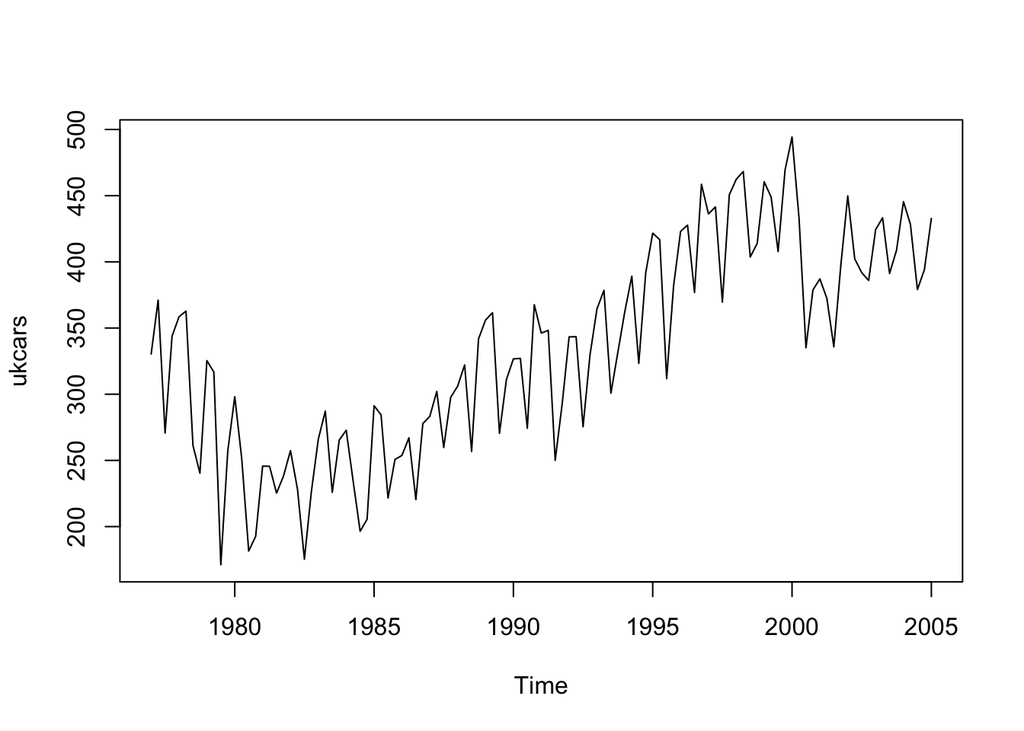

```r
data(ukcars)
plot(ukcars)
```

Yes there is both seasonal fluctuations and a trend. The seasonally fluctuations are shown from the sharp peaks and valleys of the graph. There seems to a high point once each each and also a low point each year. The trend is shown by the more spaced out peaks and valleys mainly seen by the decrease from 1970s to 1980s, the increase from 1985 to 2000 and a slight decrease after 2000.

## Use a classical decomposition to calculate the trend-cycle and seasonal indices.

```r
fitd <- decompose(ukcars)
```

## Do the results support the graphical interpretation from part (a)?

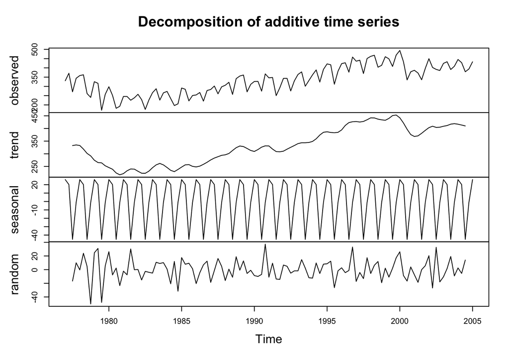

```r
plot(fitd)
```

Yes the results support exactly what was interpreted in part a. If you look at the trend graph you can see that there is a decrease in UK cars observed from the late 1970s to 1980,then there is a steady incline from 1980s to 2000 and finally a slight decline after 2000. If you look at the seasonal graph you can see that at the beginning of every year there is a spike and then it decreases till the middle of the year and then starts to increase back to the peak at the beginning of the following year.

## Compute and plot the seasonally adjusted data.

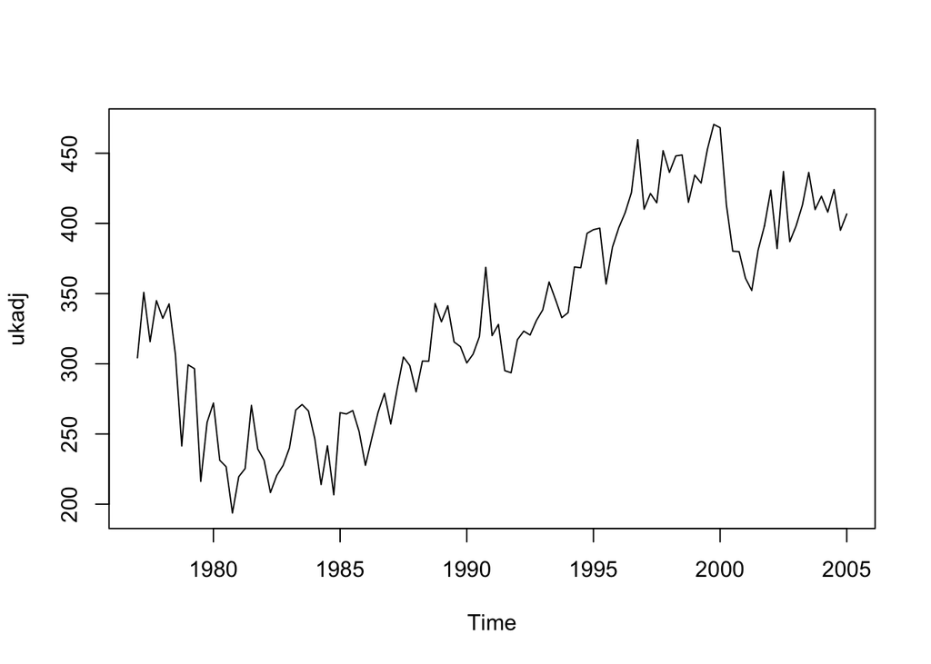

```r
ukadj <- seasadj(fitd)
plot(ukadj)
```

## Change one observation to be an outlier (e.g., add 500 to one observation), and recompute the seasonally adjusted data. What is the effect of the outlier?

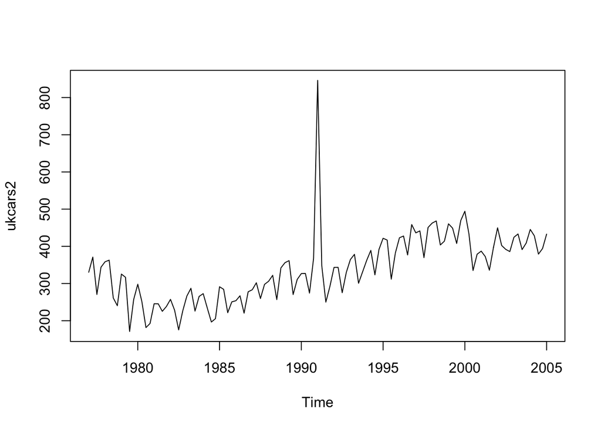

```r
#Creating the outlier at the 57th point in the data set by adding 500 to its value
ukcars2 <- ts(c(ukcars[1:56],ukcars[57]+500,ukcars[58:113]),start=c(1977,1),frequency=4)
plot(ukcars2)
```

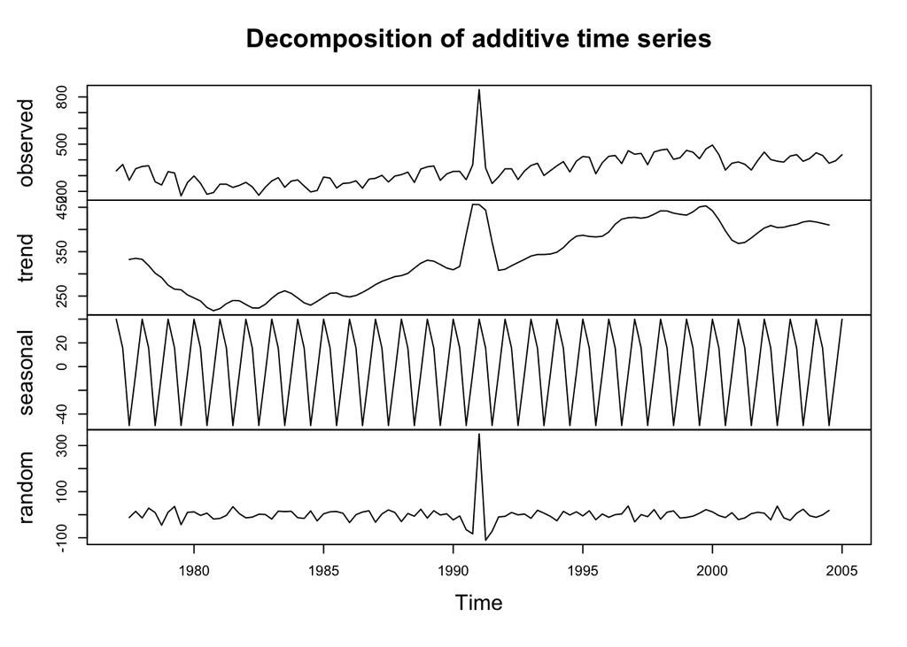

```r
#Decomposing to calculate the trend-cycle and seasonal indices
fitd2 <- decompose(ukcars2)
plot(fitd2)
```

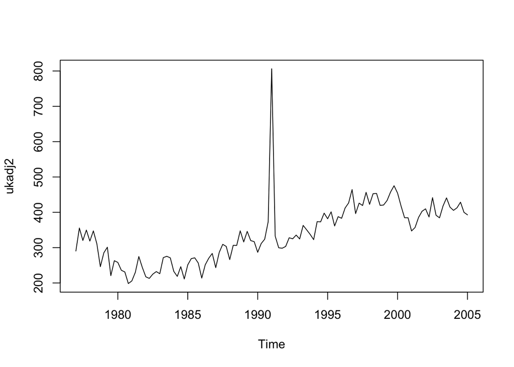

```r
#Computing the seasonally adjusted data
ukadj2 <- seasadj(fitd2)
plot(ukadj2)
```

## Does it make any difference if the outlier is near the end rather than in the middle of the time series?

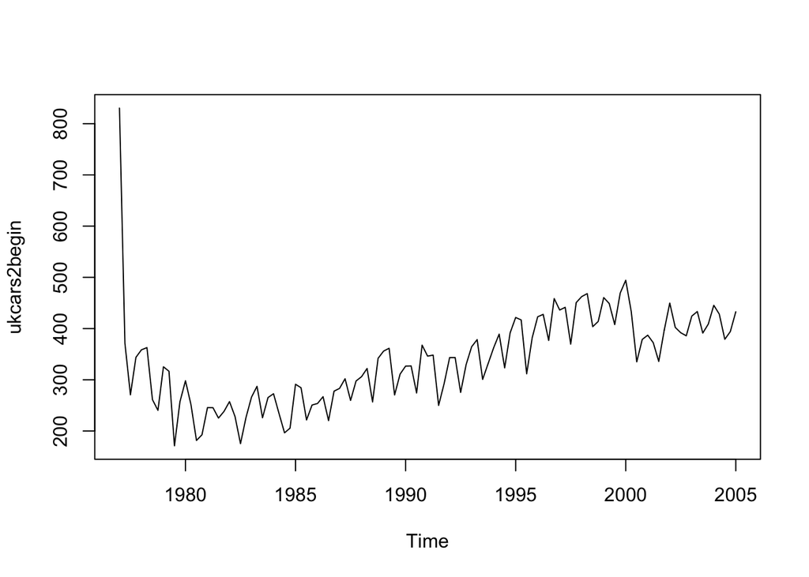

```r
#Creating an outlier at the beginning of the data set
ukcars2begin <- ts(c(ukcars[1]+500, ukcars[2:113]),start=c(1977,1),frequency=4)
plot(ukcars2begin)
```

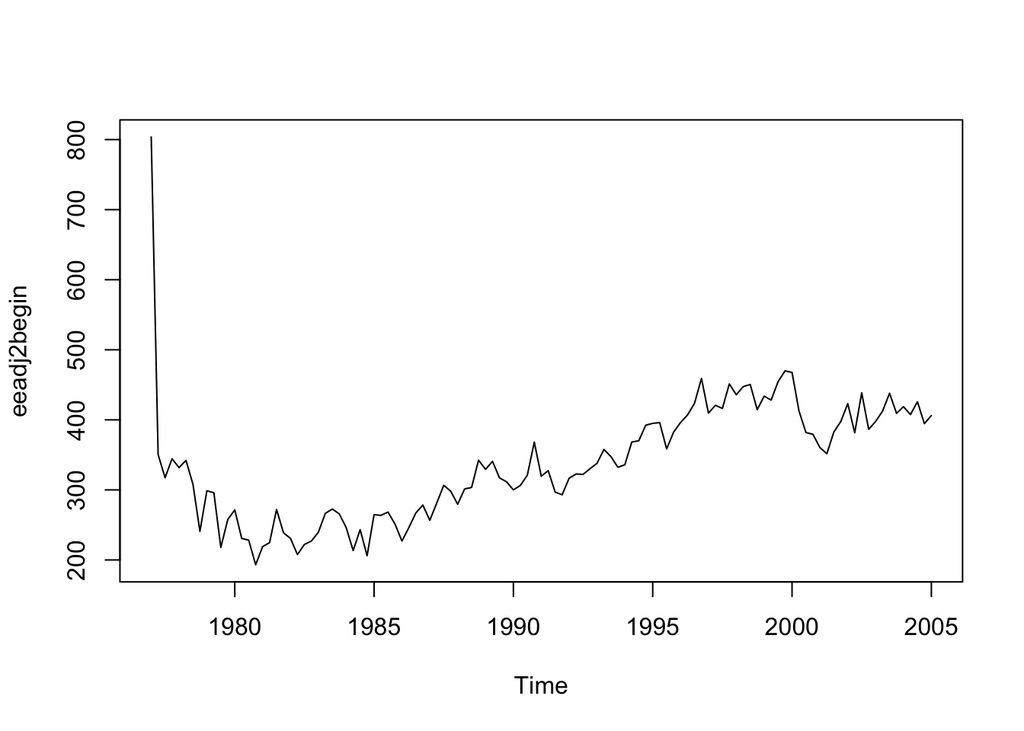

```r
#Decomposing to calculate the trend-cycle and seasonal indices for the outlier in the beginning
fitd2begin <- decompose(ukcars2begin)
#Computing the seasonally adjusted data with the outlier at the beginning
eeadj2begin <- seasadj(fitd2begin)
plot(eeadj2begin)
```

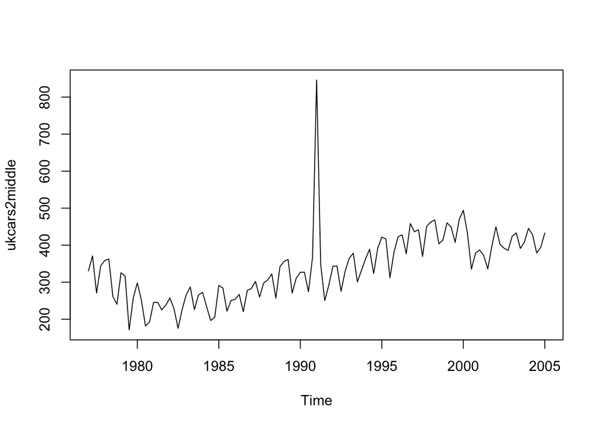

```r
#Creating an outlier at the middle of the data set
ukcars2middle <- ts(c(ukcars[1:56], ukcars[57]+500, ukcars[58:113]), start=c(1977,1), frequency=4)
plot(ukcars2middle)
```

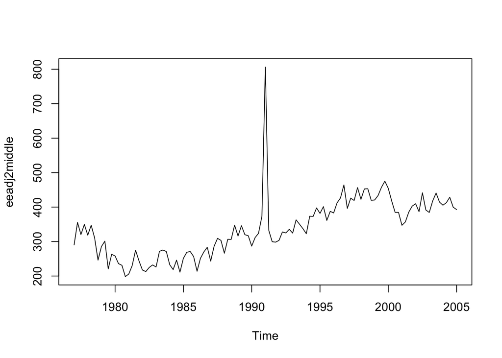

```r
#Decomposing to calculate the trend-cycle and seasonal indices for the outlier in the middle
fitd2middle <- decompose(ukcars2middle)
#Computing the seasonally adjusted data with the outlier at the middle
eeadj2middle <- seasadj(fitd2middle)
plot(eeadj2middle)
```

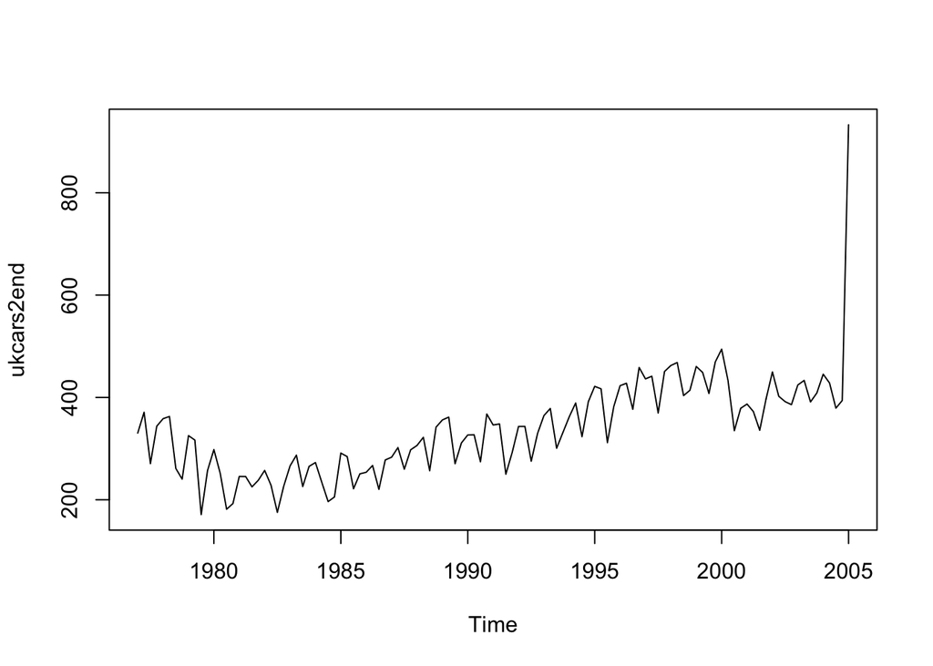

```r
#Creating an outlier at the end of the data set
ukcars2end <- ts(c(ukcars[1:112], ukcars[113]+500), start=c(1977,1), frequency = 4)
plot(ukcars2end)
```

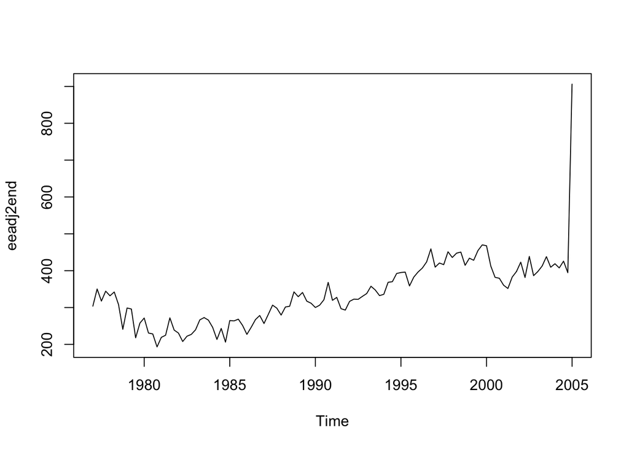

```r
#Decomposing to calculate the trend-cycle and seasonal indices for the outlier in the end
fitd2end <- decompose(ukcars2end)
#Computing the seasonally adjusted data with the outlier at the end
eeadj2end <- seasadj(fitd2end)
plot(eeadj2end)
```

## Use STL to decompose the series

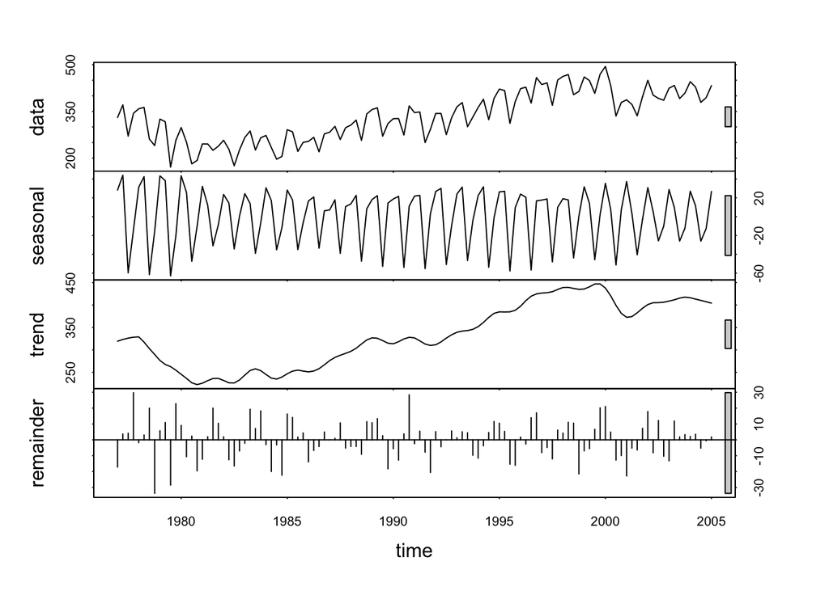

```r
fit <- stl(ukcars, s.window=5)
plot(fit)
```

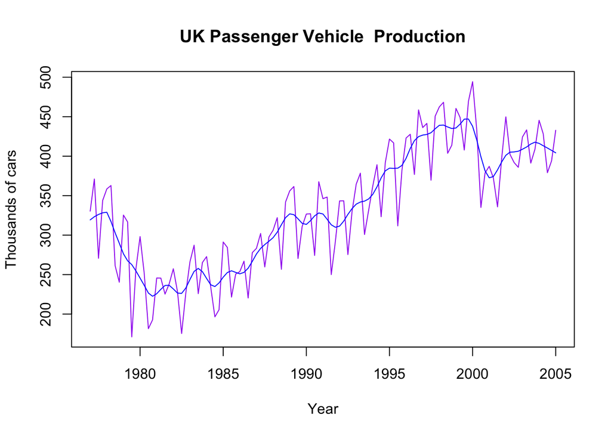

```r
plot(ukcars, col="purple",
     main="UK Passenger Vehicle  Production",
     ylab="Thousands of cars", xlab="Year")
lines(fit$time.series[,2],col="blue",ylab="Trend")
```

The purple line is the data set and the blue line is a graph of the trend.